# Lesson 5 - Plot all the things! From Data Exploration to Publication-Quality Figures

[figure not shown]

**Objective:** At the end of this session you will be able to use `ggplot2` to make a ton of different types of plots with your data for both for data exploration and for publication-quality figures.

#### Highlighting

`grey background` - a package, function, code, command or directory  
*italics* - an important term or concept or an individual file or folder  
**bold** - heading or a term that is being defined  
blue text - named or unnamed hyperlink

#### Packages Used in This Lesson

The following packages are used in this lesson:

`tidyverse` (`ggplot2`, `tidyr`, `dplyr`, `forcats`)  
`RColorBrewer`  
`viridis`  
`gridExtra`  
`ggrepel`  
`ggbeeswarm`  
`ggthemes`  
`ggpubr`  
`UpSetR`

Please install and load these packages for the lesson. In this document I will load each package separately, but I will not be reminding you to install the package. Remember: these packages may be from CRAN OR Bioconductor.

#### Data Files Used in This Lesson

-split_ENV_pitlatrine.csv  
-long_SPE_pitlatrine.csv  
-SPE_pitlatrine.csv

These files can be downloaded at https://github.com/eacton/CAGEF/tree/master/Lesson_5/data. Right-click on the filename and select ‘Save Link As…’ to save the file locally. The files should be saved in the same folder you plan on using for your R script for this lesson.

Or click on the blue hyperlink at the start of the README.md at https://github.com/eacton/CAGEF/tree/master/Lesson_5 to download the entire folder at DownGit.

## Intro to the Grammar of Graphics

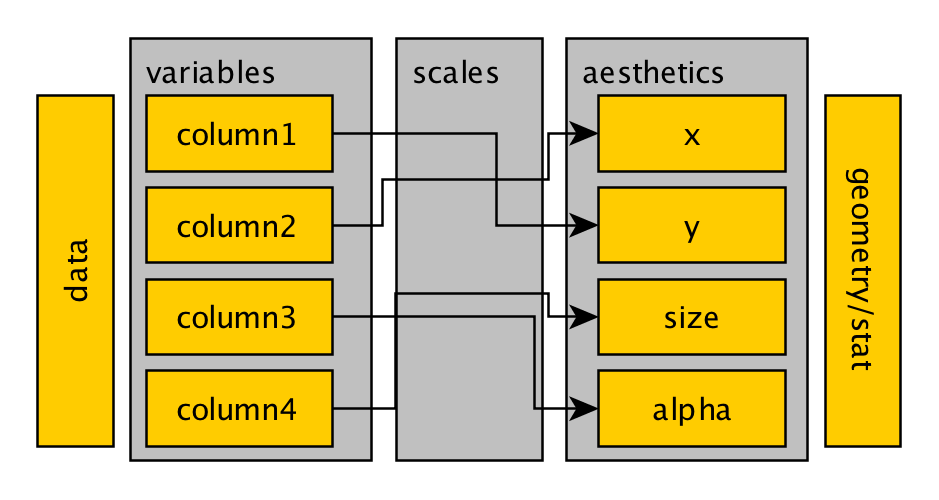

(Figure borrowed from Paul Hiemstra)

**Grammar of graphics:** a language to be able to communicate about what we are plotting programatically

- The **aesthetics** are how the data is mapped visual properties. For example, the data being plotted or represented by a shape or colour. This data could be represented in multiple ways. A plot can have multiple layers (for example, a scatterplot with a regression line).
- Lines, bars, and points are examples of **geometric objects (geoms)** that could be used to present the data.
- The data units need to be converted to physical units in order to be displayed. This uses **scaling** and a coordinate system (position adjustment for where is our pixel going). Other **statistical transformations** can also occur, such as aggregating data, jittering, density estimates, a boxplot and binning.
- **Facetting** allows us to plot subsets of the data.

This grammar allows very specific control over your plot and the ability to change features (easily). Plots can be scaled and made pretty enough for publication quality images.

`ggplot2` was made to interact well with tidy (long) datasets. I have found that if someone is spending lots of time figuring out how to make a scatterplot, his or her data is probably not in the correct format.

## The Grammar of Graphics in Action: Making Figures with ggplot2

#### Dataset: Sequencing of the V3-V5 hypervariable regions of the 16S rRNA gene

16S rRNA sequencing of 30 latrines from Tanzania and Vietnam at different depths (multiples of 20cm). Microbial abundance is represented in Operational Taxonomic Units (OTUs). Operational Taxonomic Units (OTUs) are groups of organisms defined by a specified level of DNA sequence similarity at a marker gene (e.g. 97% similarity at the V4 hypervariable region of the 16S rRNA gene). Intrinsic environmental factors such as pH, temperature, organic matter composition were also recorded.

We have 2 csv files:

1. A metadata file (Naming conventions: [Country_LatrineNo_Depth]) with sample names and environmental variables.
2. OTU abundance table.

B Torondel, JHJ Ensink, O Gunvirusdu, UZ Ijaz, J Parkhill, F Abdelahi, V-A Nguyen, S Sudgen, W Gibson, AW Walker, and C Quince. Assessment of the influence of intrinsic environmental and geographical factors on the bacterial ecology of pit latrines Microbial Biotechnology, 9(2):209-223, 2016. DOI:10.1111/1751-7915.12334

### Scatterplot

I have saved a version of the OTU table in tidy format (which we created in Lesson 3 - split_dat). As well as a modified version of the metadata table.

Let’s read our data tables in and also load `ggplot2`. We will be using a variety of packages today that are grouped in `tidyverse`, so let’s load `tidyverse`. You can see in the package startup message that `ggplot2` is one of the attached packages.

```r
library(tidyverse)
dat <- read_csv("data/long_SPE_pitlatrine.csv", col_types = 'ccici')
ndat <- read_csv("data/split_ENV_pitlatrine.csv", col_types = 'cccnnnn')
```

Let’s build a plot by adding components one by one to see how the grammar of graphics is implemented in `ggplot2`. To start, we of course need to input our data. However, if that is all we input, what we get back is a blank graphic. We have not yet said what we want to plot and how we want to plot it.

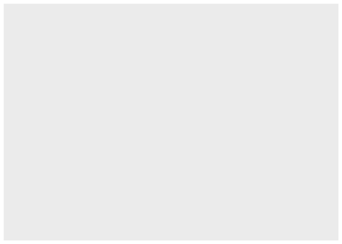

```r
ggplot(ndat)
```

We have, however, created a *ggplot object*. This is a list of 9 parameters: data, layers, scales, mapping, theme, coordinates, facet, plot environment, and labels. Luckily there are some defaults, so we don’t have to specify everything, but you can start to see how ggplot objects are highly customizable.

```r
str(ggplot(ndat))
```

```
## List of 9
##  $ data       :Classes 'spec_tbl_df', 'tbl_df', 'tbl' and 'data.frame':  81 obs. of  7 variables:
##   ..$ Country       : chr [1:81] "Tanzania" "Tanzania" "Tanzania" "Tanzania" ...
##   ..$ Latrine_Number: chr [1:81] "2" "2" "2" "2" ...
##   ..$ Depth         : chr [1:81] "1" "10" "12" "2" ...
##   ..$ pH            : num [1:81] 7.82 9.08 8.84 6.49 6.46 7.69 7.48 7.6 7.55 7.68 ...
##   ..$ Temp          : num [1:81] 25.1 24.2 25.1 29.6 27.9 28.7 29.8 25 28.8 28.9 ...
##   ..$ TS            : num [1:81] 14.5 37.8 71.1 13.9 29.4 ...
##   ..$ CODt          : num [1:81] 874 102 35 389 161 57 107 62 384 372 ...
##   ..- attr(*, "spec")=
##   .. .. cols(
##   .. ..   Country = col_character(),
##   .. ..   Latrine_Number = col_character(),
##   .. ..   Depth = col_character(),
##   .. ..   pH = col_number(),
##   .. ..   Temp = col_number(),
##   .. ..   TS = col_number(),
##   .. ..   CODt = col_number()
##   .. .. )
##  $ layers     : list()
##  $ scales     :Classes 'ScalesList', 'ggproto', 'gg' <ggproto object: Class ScalesList, gg>
##     add: function
##     clone: function
##     find: function
##     get_scales: function
##     has_scale: function
##     input: function
##     n: function
##     non_position_scales: function
##     scales: NULL
##     super:  <ggproto object: Class ScalesList, gg>
##  $ mapping    : Named list()
##   ..- attr(*, "class")= chr "uneval"
##  $ theme      : list()
##  $ coordinates:Classes 'CoordCartesian', 'Coord', 'ggproto', 'gg' <ggproto object: Class CoordCartesian, Coord, gg>
##     aspect: function
##     backtransform_range: function
##     clip: on
##     default: TRUE
##     distance: function
```

[output cut: 21 more lines]

```
##     draw_labels: function
##     draw_panels: function
##     finish_data: function
##     init_scales: function
##     map_data: function
##     params: list
##     setup_data: function
##     setup_params: function
##     shrink: TRUE
##     train_scales: function
##     vars: function
##     super:  <ggproto object: Class FacetNull, Facet, gg>
##  $ plot_env   :<environment: R_GlobalEnv>
##  $ labels     : Named list()
##  - attr(*, "class")= chr [1:2] "gg" "ggplot"
```

The next step is to choose the data we are plotting **(aesthetics)**. At this point the data can be **scaled** and the axes appear. We have not yet specified how we want the data plot, just which data should be plotted. In practice, people usually omit ‘mapping =’, but it is a good reminder that mapping is, in fact, what we are doing.

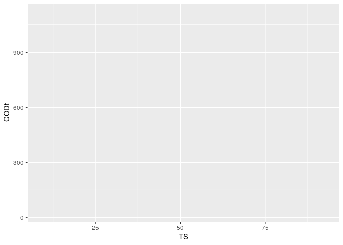

```r
ggplot(ndat, mapping = aes(x = TS, y = CODt))
```

We now have chosen the **geometric object (geom)** with which to plot our data, in this case a point. A geom could be a line, a bar, a boxplot - you can type geom_ and then `Tab` to see all of the available options. *Autocomplete* can also be helpful for remembering syntax.

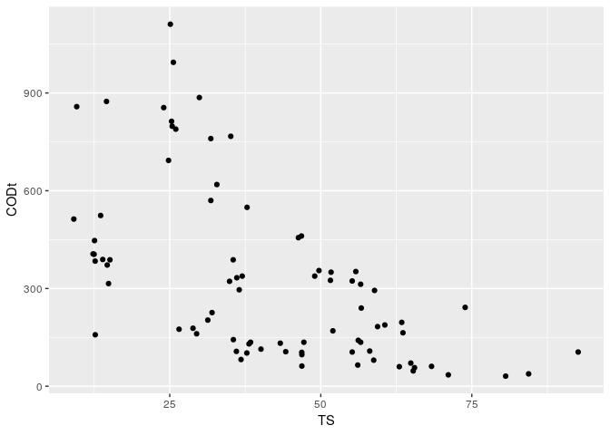

```r
ggplot(ndat, aes(x=TS, y=CODt)) + geom_point()
```

The **aesthetic** of colour which is mapped to Country can be specified when ‘x’ and ‘y’ (the data to be plotted) are specified using `aes()`. Colour can alternatively be specified using `geom_point(aes())` since it is a description of the points being plotted. I usually do the former, because it is more likely that I will change *how* I plot a figure (points, lines, bars) versus *what* I plot in a figure (TS, CODt, Country). There are minor implications for each of these choices.

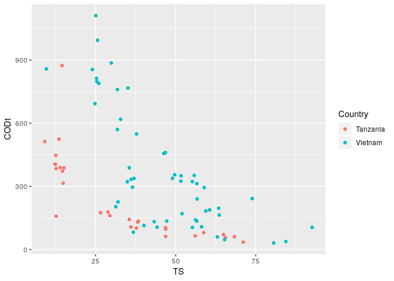

```r
ggplot(ndat, aes(x=TS, y=CODt, colour = Country)) + geom_point()
```

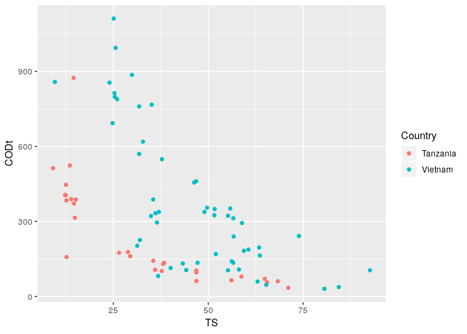

```r
#is equivalent-ish to
ggplot(ndat, aes(x=TS, y=CODt)) + geom_point(aes(colour = Country))
```

Some of our data points seem to be crushed near the x-axis. We can **scale** the y-axis to fix this. When we start customizing our plot, our code starts to get a bit harder to read on one line. We can create each specification on a new line by ending each line with `+`.

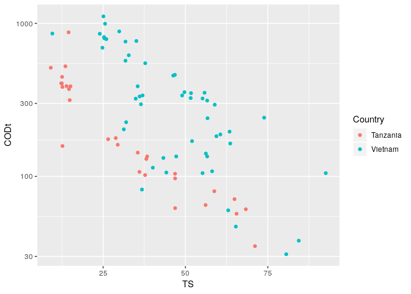

```r
ggplot(ndat, aes(x=TS, y=CODt, colour = Country)) +
  geom_point() +
  scale_y_log10()
```

Keep in mind that scaling does not change the data, but rather the representation of the data. The y-axis has been scaled. This is different than taking the log10 of the y data.

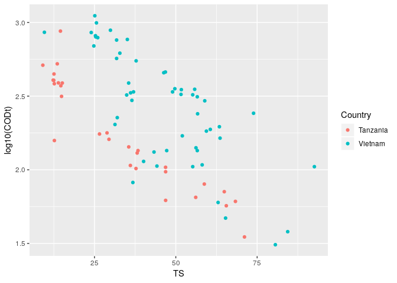

```r
ggplot(ndat, aes(x=TS, y=log10(CODt), colour = Country)) +
  geom_point()
```

The placement of the points looks the same, but the first graph is scaling the axis while the second graph has changed the data to a log10 scale.

#### Faceting

**Faceting** allows us to split our data into groups. Note that I have removed the colour. It is good data visualization practice to only have one attribute (colour, shading, faceting, symbols) per grouping.

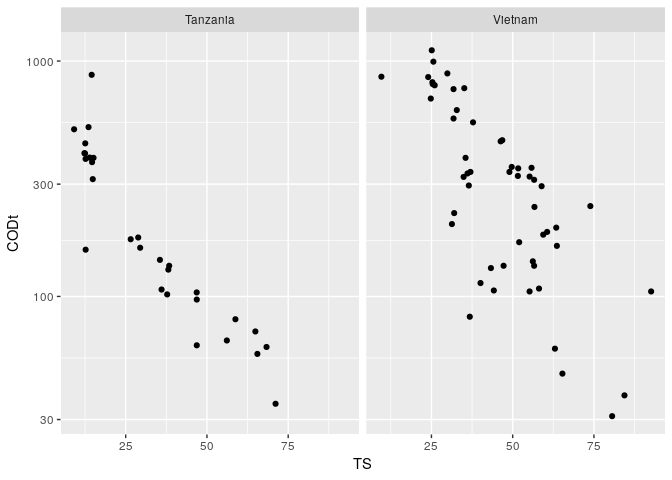

```r
ggplot(ndat, aes(x=TS, y=CODt)) +
  geom_point() +
  scale_y_log10() +
  facet_grid(~Country)
```

I could now add information from another variable as a colour in this plot. Note that if a variable is continuous instead of discrete, the colour will be a gradient.

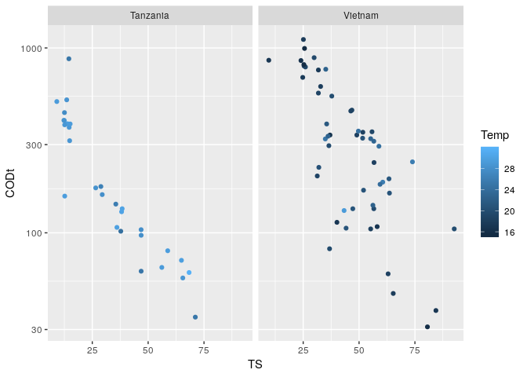

```r
ggplot(ndat, aes(x=TS, y=CODt, colour = Temp)) +
  geom_point() +
  scale_y_log10() +
  facet_grid(~Country)
```

If we really wanted to we could add another variable to the plot by changing the shape attribute. Let’s change Country to having 2 shapes and facet by the Depth of the latrine instead. Note that shape can only be used for discrete values. A quick reference key for shapes can be found in the ‘Cookbook for R’ (http://www.cookbook-r.com/Graphs/Shapes_and_line_types/).

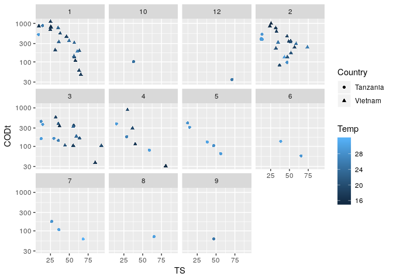

```r
ggplot(ndat, aes(x=TS, y=CODt, colour = Temp, shape = Country)) +
  geom_point() +
  scale_y_log10() +
  facet_wrap(~Depth)
```

We can now note that only Tanzania had sampling greater than 4cm of depth. There are single latrines for 4 samples. There was no latrine at a depth of 11cm. Lack of replication and a bias towards Tanzania for the higher depths is something we should keep in mind while looking at this data. Depending on the question we are trying to answer, we may want to remove some of this data.

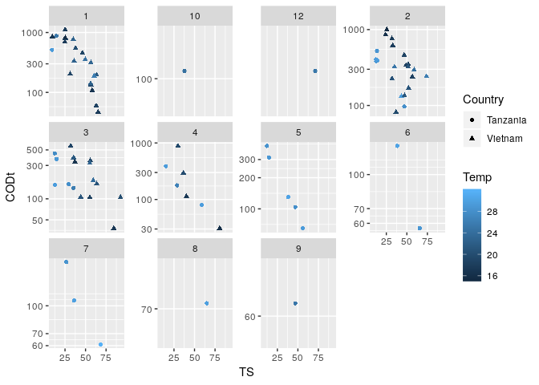

```r
ggplot(ndat, aes(x=TS, y=CODt, colour = Temp, shape = Country)) +
  geom_point() +
  scale_y_log10() +
  facet_wrap(~Depth, scales = "free_y")
```

#### Regression Lines

You can also add **statistical transformations** to your plots. Again, take a look at stat_ then `Tab` to see the list of options. In this case let’s separately fit a linear regression line to CODt vs TS for each country. The grey area around the line is the confidence interval (default=0.95) and can be removed with the additional call to stat_smooth of `se = FALSE`.

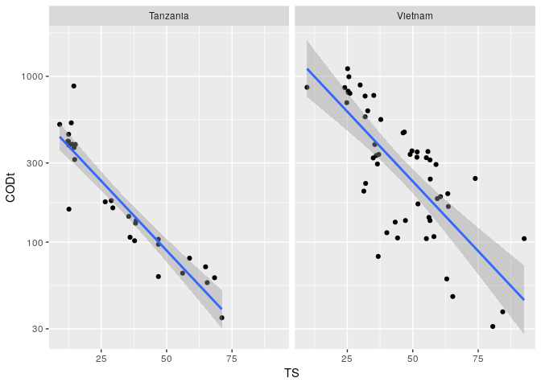

```r
ggplot(ndat, aes(x=TS, y=CODt)) +
  geom_point() +
  scale_y_log10() +
  facet_grid(~Country) +
  stat_smooth(method = lm)
```

A linear model is not always the best fit. The method of calculating the smoothing function can be changed to other provided functions (such as loess, used below) or can be a custom formula. Note that I changed the confidence interval by modifying `level=0.8`. geoms can be made more transparent with the alpha parameter, which is set to 0.3 in the following code so that the emphasis is on the regression line rather than the points.

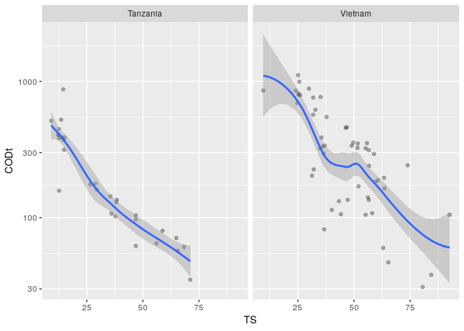

```r
ggplot(ndat, aes(x=TS, y=CODt)) +
  geom_point(alpha = 0.3) +
  scale_y_log10() +
  facet_grid(~Country) +
  stat_smooth(method = loess, level = 0.8)
```

## Exploring different types of plots

### Density Plots

We are making a density plot for OTUs by Country. I have set alpha (transparency) to 0.3 so that we can see both countries on our plot.

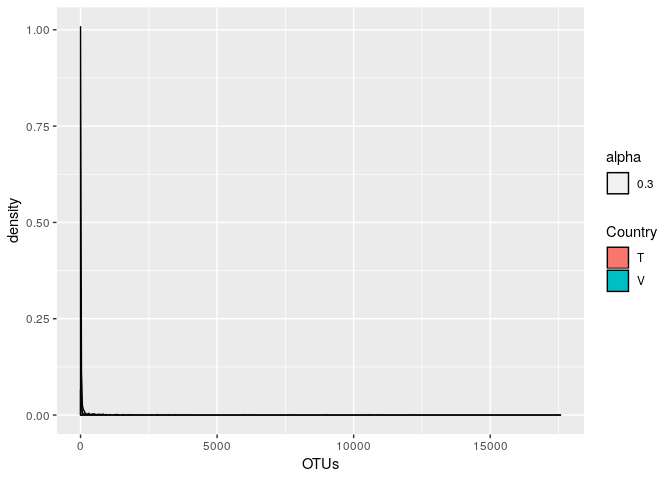

```r
ggplot(dat, aes(x=OTUs, fill=Country, alpha=0.3)) +
    geom_density()
```

The first thing to notice is that everything is clumped at 0. This is because we have not filtered our data frame to remove all observations where OTUs are zero. Here we filter to have at least 2 OTUs. The other thing to notice is that there is a long tail where there will only be a few observations. It will be necessary to change the x-axis to see our data. This is done by setting ‘limits’ (lower and upper boundaries) on the x-axis with `xlim()`. Note that R gives us a warning that we are not viewing 158 of our 4212 rows. We can add a rug geom to see each value.

```
## Warning: Removed 158 rows containing non-finite values (stat_density).
```

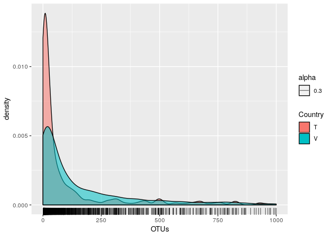

```r
fdat <- dat %>% filter(OTUs >=2)

ggplot(fdat, aes(x=OTUs, fill=Country, alpha=0.3)) +
    geom_density() +
  geom_rug() +
  xlim(0, 1000)
```

### Histograms

```
## Warning: Removed 158 rows containing non-finite values (stat_bin).
```

```
## Warning: Removed 4 rows containing missing values (geom_bar).
```

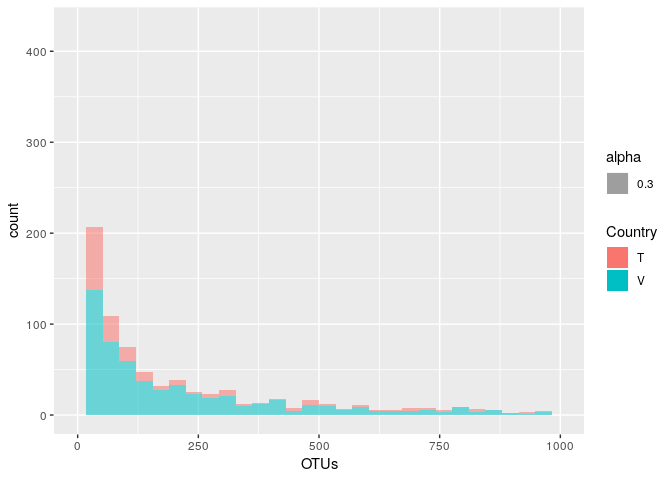

```r
ggplot(fdat, aes(x=OTUs, fill=Country, alpha=0.3)) +
    geom_histogram() +
  xlim(0,1000)
```

Instead of having the countries information stacked, we may want to see the data side by side. This can be done with the parameter position set to ‘dodge’. A rug geom can also be added to a histogram. Note that the binwidth has been changed and limits have also been set on the y-axis.

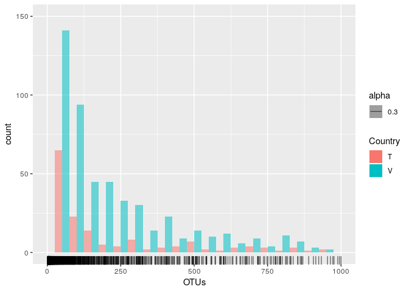

```r
ggplot(fdat, aes(x=OTUs, fill=Country, alpha=0.3)) +
    geom_histogram(binwidth = 50, position = "dodge") +
  xlim(0,1000) +
  ylim(0,150) +
  geom_rug()
```

**Challenge**

Create a bar plot of OTUs per country and use the filled in colour to represent Taxa.

#### Controlling the order categorical variables in your legend

We will talk about customizing plots later in this lesson, but the last line of code is one way to remove the legend title (by making the legend title ‘blank’).

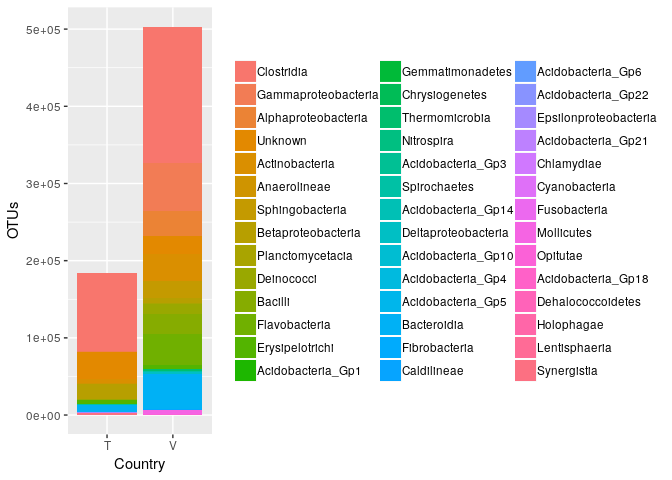

```r
ggplot(fdat, aes(x=Country, y=OTUs, fill=fct_reorder2(Taxa, Country, OTUs))) +
    geom_bar(stat = "identity") +
  theme(legend.title = element_blank())
```

You can alternate between ‘stacked’ or ‘dodged’ (as we did with the histogram) for whether your bars are on top of each other or next to each other when splitting by a factor or categorical variable.

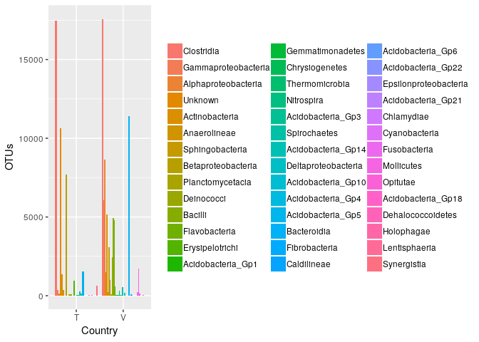

```r
ggplot(fdat, aes(x=Country, y=OTUs, fill=fct_reorder2(Taxa, Country, OTUs))) +
    geom_bar(stat = "identity", position = "dodge") +
  theme(legend.title = element_blank())
```

You can have your bars horizonal instead of vertical by using `coord_flip()`.

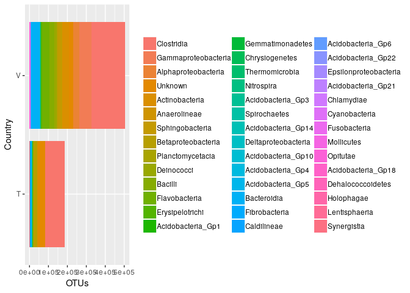

```r
ggplot(fdat, aes(x=Country, y=OTUs, fill=fct_reorder2(Taxa, Country, OTUs))) +
    geom_bar(stat = "identity") +
  theme(legend.title = element_blank()) +
  coord_flip()
```

### Boxplots

Boxplots are a great way to visualize summary statistics for your data. As a reminder, the thick line in the center of the box is the median. The upper and lower ends of the box are the first and third quartiles (or 25th and 75th percentiles) of your data. The whiskers extend to the largest value no further than 1.5*IQR (inter-quartile range - the distance between the first and third quartiles). Data beyond these whiskers are considered outliers and plotted as individual points. This is a quick way to see how comparable your samples or variables are.

We are going to use boxplots to see the distribution of OTUs per Taxa across all samples.

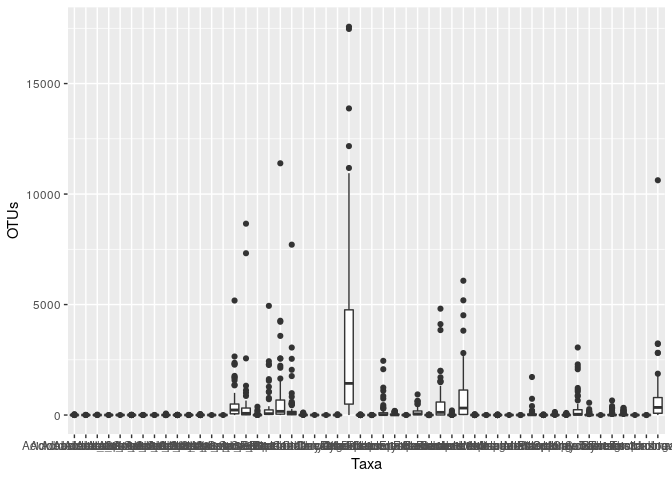

```r
ggplot(dat, aes(x = Taxa, y = OTUs)) +
  geom_boxplot()
```

While we are going to address customization and what theme elements are shortly, but I think showing you now how to rotate the x-axis labels is appropriate. Essentially we are taking the text on the x-axis and rotating it by 90 degrees.

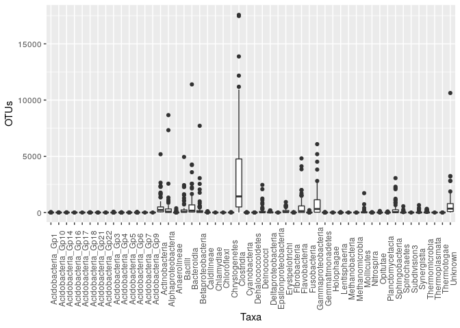

```r
ggplot(dat, aes(x = Taxa, y = OTUs)) +
  geom_boxplot() +
  theme(axis.text.x = element_text(angle=90))
```

We then justify the labels such that they align with the x-axis.

You may ask why this is a horizontal (hjust) justification, when it seems like moving the labels upwards towards the x-axis should be a vertical (vjust) justification. If you look in the help menu at `element_text()` you will see that the justification is carried out before the rotation. While we can specify the parameters of `element_text()` in any order, this does not change the order they are executed in the function.

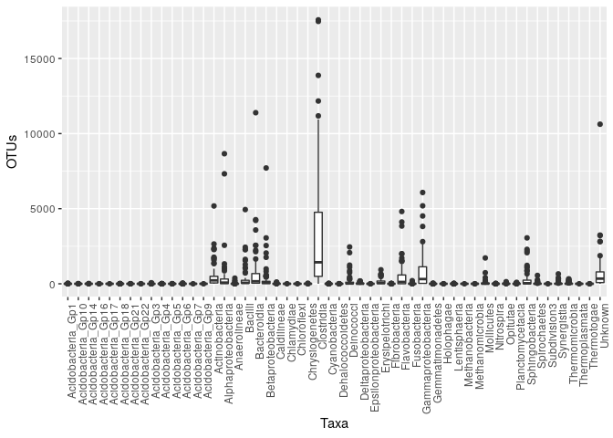

```r
ggplot(dat, aes(x = Taxa, y = OTUs)) +
  geom_boxplot() +
  theme(axis.text.x = element_text(angle=90, hjust = 1))
```

While it is clear that Clostridia is the most represented taxa, it is difficult to tell whether some other taxa have no representation, or if they are lowly represented. Transforming to a log scale on the y-axis will sort this out for us.

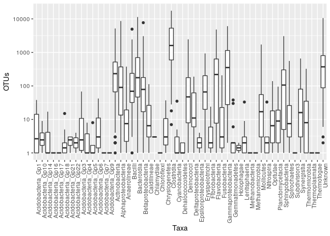

```r
ggplot(dat, aes(x = Taxa, y = OTUs)) +
  geom_boxplot() +
  theme(axis.text.x = element_text(angle=90, hjust=1)) +
  scale_y_log10()
```

For now, let’s just keep the Taxa that are common to both countries and have greater than 1 OTU. To do this we can filter for rows with greater than or equal to 2 OTUs. We then group by Country and Taxa to get Country-specific information about Taxa, and count the number of entries, keeping only Taxa that are shown to appear in more than one sample. We then need to `ungroup()` to select our final list or we will end up with a grouped object. We use the `duplicated()` function to retain those Taxa that were found twice (ie. in both countries).

The `%in%` function returns a logical vector of whether there is a match or not for its first argument in its second argument. It is useful for subsetting.

We can facet our plot by Country to verify we have only commonly appearing OTUs.

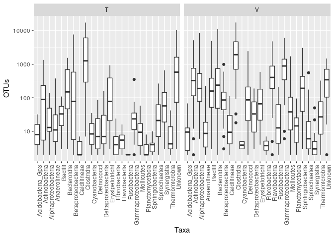

```r
keep <- fdat %>%
  group_by(Country, Taxa) %>%
  summarize(n = n()) %>%
  filter(n > 1) %>%
  ungroup() %>%
  select(Taxa) %>%
  filter(duplicated(.))

subfdat <- fdat %>% filter(Taxa %in% keep$Taxa)

ggplot(subfdat , aes(x = Taxa, y = OTUs)) +
  geom_boxplot() +
  theme(axis.text.x = element_text(angle=90, hjust=1)) +
  scale_y_log10() +
  facet_grid(~Country)
```

We will be using this graph as a base for customization later in the lesson.

### Beeswarm Plots

Even though boxplots give us summary statistics on our data, it is useful to be able to see where our individual data points are. We can add the data as another layer using `geom_point()`to place dots on top of our boxplot, or use `geom_jitter()` to spread our points out a bit. However, a **beeswarm plot** places data points that are overlapping next to each other, so we can get a better picture of the distribution of our data.

I have subset the data to make a boxplot with 3 Taxa and 1 Country so that we can see the differences in geom options a bit better.

An option with `ggplot2` is to save your plot into a *ggplot object*. This works well if you know you are only changing one or two elements of your plot, and you do not want to keep retyping code. What we are going to vary here is how the data points are displayed.

```r
subdat <- dat %>% filter((Taxa=="Clostridia" | Taxa == "Unknown" | Taxa == "Bacilli") & Country == "T")

b <- ggplot(subdat, aes(x = Taxa, y = OTUs)) +
  geom_boxplot() +
  theme(axis.text.x = element_text(angle=90, hjust=1)) +
  scale_y_log10()
```

We can simply overlay the points with `geom_beeswarm()`.

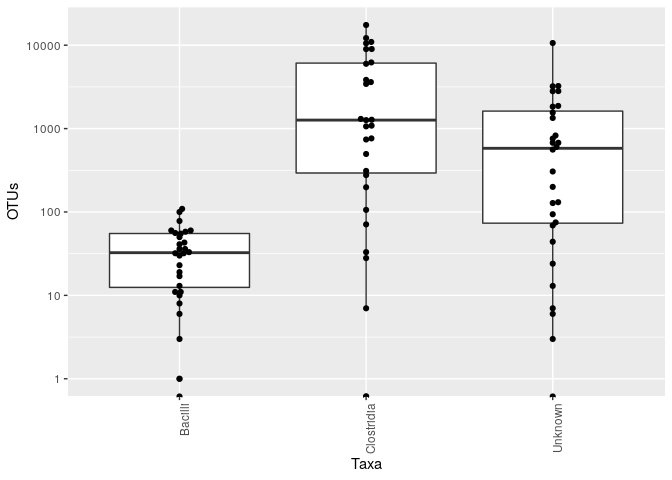

```r
library(ggbeeswarm)

b + geom_beeswarm()
```

Increasing the spacing between data points (increasing ‘cex’) can make this distribution a bit clearer.

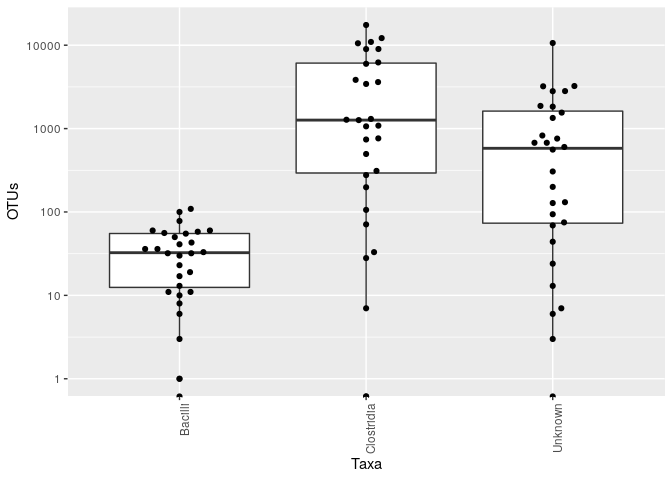

```r
b + geom_beeswarm(cex = 2.2)
```

Using `geom_quasirandom()` gives the empirical distribution of the stripplot to avoid overplotting.

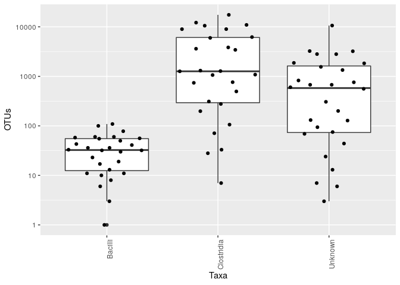

```r
b + geom_quasirandom(varwidth = TRUE)
```

Other spacing and distribution options are available at https://github.com/eclarke/ggbeeswarm.